# Delta Smelt Occurrence by Life Stage

Brian Mahardja

10/04/2022

## Load and process Delta Smelt data

Grab Delta Smelt data from the integrated fish dataset (LTMRdata package by Sam Bashevkin et al.) and produce one fish data per row. I will exclude fish with no length measurement. Note that unmeasured fish that were collected alongside measured fish were converted to have fish length per LTMRdata documentation. I converted count to integer however, since the process that Sam implemented created decimal points for counts.

Surveys included in this calculation:

1. San Francisco Bay Study
2. Suisun Marsh Study
3. Fall Midwater Trawl
4. Spring Kodiak Trawl
5. Delta Juvenile Fish Monitoring Program
6. Enhanced Delta Smelt Monitoring
7. 20-mm Survey
8. Smelt Larval Survey
9. Summer Townet Survey

```r
#Load data
data_deltasmelt <-LTMRdata::fish(sources=c("Baystudy", "Suisun", "FMWT", "SKT", "DJFMP", "EDSM", "TMM", "SLS","STN"),species="Hypomesus transpacificus", size_cutoff=NULL,remove_unknown_lengths=TRUE) %>% filter(year(Date)>=1994)

#Create time series summary
data_deltasmelt_time_summary<-data_deltasmelt %>% group_by(Source) %>% summarise(StartDate=min(Date),EndDate=max(Date))
data_deltasmelt_time_summary
```

```
## # A tibble: 9 x 3
##   Source    StartDate           EndDate
##   <chr>     <dttm>              <dttm>
## 1 20mm      1995-04-24 00:00:00 2021-07-16 00:00:00
## 2 Bay Study 1994-02-02 00:00:00 2020-12-01 00:00:00
## 3 DJFMP     1994-01-03 00:00:00 2020-12-31 00:00:00
## 4 EDSM      2016-12-15 00:00:00 2021-03-25 00:00:00
## 5 FMWT      1994-01-10 00:00:00 2020-12-15 00:00:00
## 6 SKT       2002-01-07 00:00:00 2021-04-29 00:00:00
## 7 SLS       2009-01-05 00:00:00 2021-03-17 00:00:00
## 8 STN       1994-06-15 00:00:00 2021-08-19 00:00:00
## 9 Suisun    1994-01-06 00:00:00 2021-09-23 00:00:00
```

```r
#Change count to integer
data_deltasmelt$Count<-as.integer(data_deltasmelt$Count)
#Remove zero catch data
data_deltasmelt<- data_deltasmelt%>% filter(Count>0)

#Create long form, remove data prior to 1994
data_deltasmelt_long <-data_deltasmelt[rep(1:nrow(data_deltasmelt), data_deltasmelt$Count),] %>% mutate(Count=1)
```

## Size cutoffs used for Delta Smelt

Larvae: (<20mm FL)

Juvenile: (20-58mm FL)

Adult: (>58mm FL)

### Brood year cutoff for the life stages

Larvae: brood year = calendar year

Juvenile: brood year starts in March 1st of current year to February 28th or 29th of the following year

Adult: brood year starts in June 1st of current year to May 31st of the following year

## Adult Delta Smelt

(>58 mm FL, cohort year set to June 1st - May 31st)

| Cohort Year | 0.0% | 5.0% | 10.0% | 90.0% | 95.0% | 100.0% | Sample size |
| --- | --- | --- | --- | --- | --- | --- | --- |
| 1994 | June 01 1994 | June 20 1994 | November 23 1994 | April 22 1995 | May 06 1995 | May 31 1995 | 2017 |
| 1995 | June 01 1995 | September 25 1995 | October 25 1995 | May 10 1996 | May 16 1996 | May 31 1996 | 14341 |
| 1996 | June 03 1996 | June 03 1996 | June 08 1996 | May 18 1997 | May 27 1997 | May 31 1997 | 951 |
| 1997 | June 01 1997 | June 08 1997 | June 20 1997 | May 01 1998 | May 11 1998 | May 30 1998 | 1694 |
| 1998 | June 01 1998 | November 28 1998 | December 15 1998 | May 02 1999 | May 11 1999 | May 29 1999 | 4773 |
| 1999 | June 01 1999 | October 07 1999 | November 08 1999 | March 07 2000 | April 03 2000 | May 31 2000 | 5673 |
| 2000 | June 07 2000 | October 05 2000 | November 08 2000 | March 19 2001 | April 27 2001 | May 31 2001 | 1686 |
| 2001 | June 01 2001 | July 03 2001 | August 30 2001 | March 06 2002 | March 18 2002 | May 25 2002 | 1589 |
| 2002 | June 04 2002 | October 16 2002 | December 07 2002 | April 28 2003 | May 02 2003 | May 31 2003 | 2436 |
| 2003 | June 01 2003 | October 09 2003 | January 12 2004 | April 19 2004 | April 29 2004 | May 20 2004 | 2046 |
| 2004 | June 02 2004 | October 12 2004 | November 23 2004 | May 04 2005 | May 16 2005 | May 31 2005 | 2103 |
| 2005 | June 01 2005 | June 24 2005 | July 08 2005 | April 17 2006 | May 10 2006 | May 31 2006 | 1427 |
| 2006 | June 01 2006 | June 06 2006 | June 21 2006 | April 05 2007 | April 05 2007 | May 22 2007 | 1091 |
| 2007 | June 06 2007 | October 03 2007 | December 12 2007 | April 22 2008 | April 29 2008 | May 30 2008 | 434 |
| 2008 | June 06 2008 | September 03 2008 | December 16 2008 | March 18 2009 | April 15 2009 | May 27 2009 | 766 |
| 2009 | June 01 2009 | August 04 2009 | October 26 2009 | April 22 2010 | April 22 2010 | May 26 2010 | 971 |
| 2010 | June 07 2010 | July 19 2010 | August 16 2010 | April 06 2011 | April 11 2011 | May 25 2011 | 904 |
| 2011 | June 01 2011 | September 07 2011 | October 07 2011 | April 17 2012 | May 02 2012 | May 25 2012 | 2112 |
| 2012 | June 01 2012 | June 29 2012 | July 13 2012 | March 07 2013 | April 04 2013 | May 24 2013 | 870 |
| 2013 | June 07 2013 | July 24 2013 | November 13 2013 | April 08 2014 | April 10 2014 | May 08 2014 | 602 |
| 2014 | June 02 2014 | July 16 2014 | September 11 2014 | February 12 2015 | March 11 2015 | May 06 2015 | 190 |
| 2015 | July 01 2015 | August 03 2015 | September 01 2015 | April 04 2016 | April 04 2016 | May 23 2016 | 58 |
| 2016 | June 07 2016 | December 08 2016 | December 08 2016 | March 01 2017 | March 08 2017 | May 31 2017 | 465 |
| 2017 | June 07 2017 | July 20 2017 | August 09 2017 | February 14 2018 | March 07 2018 | March 22 2018 | 84 |
| 2018 | July 09 2018 | September 17 2018 | September 24 2018 | February 11 2019 | February 12 2019 | March 03 2019 | 45 |
| 2019 | November 29 2019 | November 29 2019 | December 04 2019 | March 05 2020 | March 16 2020 | March 16 2020 | 18 |

Note that adult Delta Smelt can linger for more than a year (i.e, 1+ year old Delta Smelt). 2-year old Delta Smelt have even been observed in the past. This is why the first adult smelt can sometimes show up in June or July in the table. This phenomenon of 1+ year old Delta Smelt appear to be more common in the 1990s (or whenever smelt were more abundant). Example below:

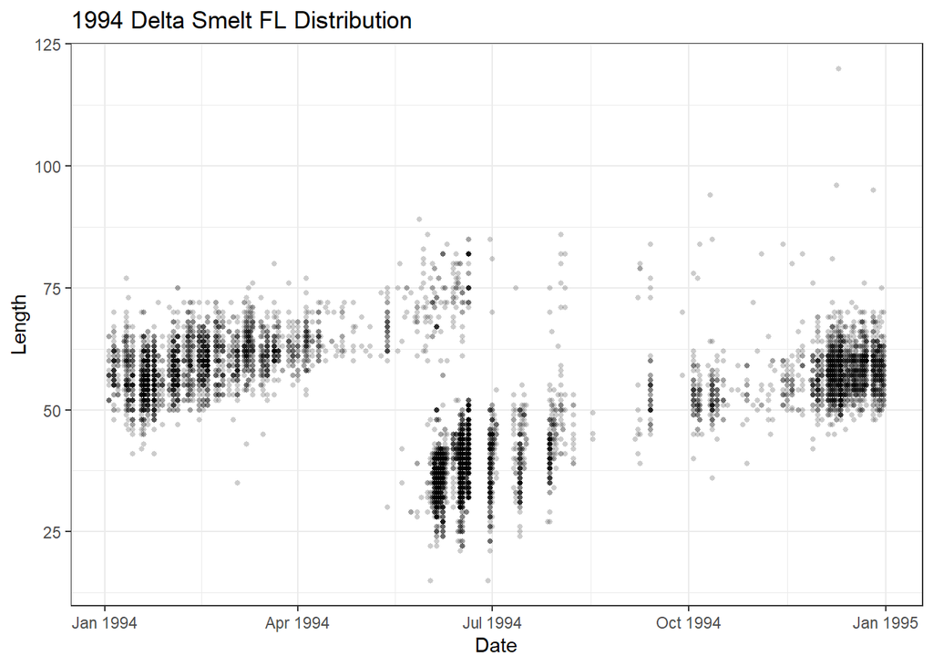

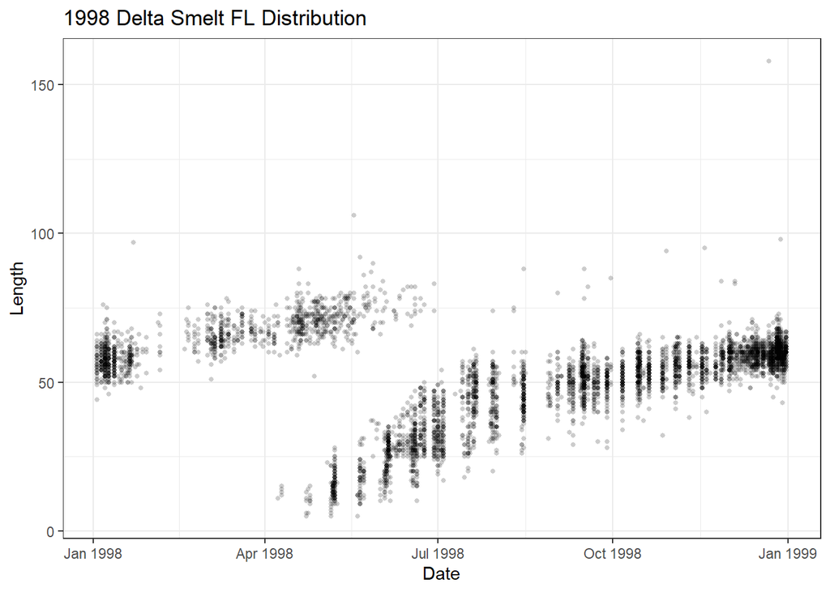

## Juvenile Delta Smelt

(20-58 mm FL, cohort year set to March 1st - February 28th/29th)

| Cohort Year | 0.0% | 5.0% | 10.0% | 90.0% | 95.0% | 100.0% | Sample size |
| --- | --- | --- | --- | --- | --- | --- | --- |
| 1994 | March 02 1994 | June 05 1994 | June 07 1994 | December 15 1994 | January 04 1995 | February 24 1995 | 8178 |
| 1995 | March 03 1995 | June 21 1995 | July 06 1995 | January 13 1996 | January 16 1996 | February 08 1996 | 8143 |
| 1996 | March 01 1996 | May 24 1996 | May 29 1996 | December 07 1996 | December 10 1996 | February 05 1997 | 5410 |
| 1997 | March 04 1997 | May 31 1997 | June 09 1997 | December 30 1997 | January 09 1998 | February 25 1998 | 3028 |
| 1998 | March 04 1998 | June 05 1998 | June 18 1998 | December 30 1998 | January 08 1999 | February 23 1999 | 3060 |
| 1999 | March 08 1999 | May 28 1999 | June 09 1999 | December 20 1999 | January 05 2000 | February 22 2000 | 5048 |
| 2000 | March 07 2000 | May 31 2000 | June 12 2000 | December 15 2000 | January 30 2001 | February 26 2001 | 5425 |
| 2001 | March 02 2001 | May 05 2001 | May 05 2001 | October 10 2001 | October 10 2001 | February 05 2002 | 2490 |
| 2002 | March 06 2002 | May 14 2002 | May 20 2002 | October 08 2002 | November 05 2002 | January 24 2003 | 987 |
| 2003 | May 06 2003 | June 05 2003 | June 12 2003 | January 27 2004 | January 27 2004 | February 24 2004 | 1324 |
| 2004 | March 09 2004 | May 20 2004 | May 20 2004 | October 04 2004 | November 08 2004 | February 24 2005 | 984 |
| 2005 | March 02 2005 | May 12 2005 | May 16 2005 | December 05 2005 | January 18 2006 | February 27 2006 | 895 |
| 2006 | May 05 2006 | May 20 2006 | June 02 2006 | January 10 2007 | January 22 2007 | February 22 2007 | 1109 |
| 2007 | March 06 2007 | May 03 2007 | June 06 2007 | August 21 2007 | December 12 2007 | February 04 2008 | 188 |
| 2008 | April 29 2008 | May 20 2008 | May 28 2008 | January 14 2009 | January 14 2009 | February 13 2009 | 493 |
| 2009 | March 18 2009 | May 06 2009 | May 20 2009 | September 14 2009 | January 14 2010 | January 28 2010 | 557 |
| 2010 | March 10 2010 | May 10 2010 | May 10 2010 | August 11 2010 | October 04 2010 | February 10 2011 | 764 |
| 2011 | April 01 2011 | May 25 2011 | June 07 2011 | December 07 2011 | January 19 2012 | February 22 2012 | 2213 |
| 2012 | March 05 2012 | May 21 2012 | May 23 2012 | July 26 2012 | September 04 2012 | February 06 2013 | 736 |
| 2013 | April 08 2013 | May 06 2013 | May 06 2013 | September 03 2013 | September 16 2013 | February 12 2014 | 1114 |
| 2014 | March 12 2014 | April 28 2014 | May 12 2014 | August 14 2014 | December 08 2014 | January 15 2015 | 307 |
| 2015 | April 16 2015 | April 27 2015 | May 08 2015 | September 01 2015 | September 01 2015 | December 01 2015 | 164 |
| 2016 | March 09 2016 | April 13 2016 | April 27 2016 | December 22 2016 | December 28 2016 | February 08 2017 | 132 |
| 2017 | March 08 2017 | May 09 2017 | May 24 2017 | September 18 2017 | October 10 2017 | January 10 2018 | 527 |
| 2018 | May 02 2018 | July 05 2018 | July 17 2018 | November 07 2018 | December 28 2018 | February 25 2019 | 160 |
| 2019 | April 29 2019 | June 18 2019 | July 03 2019 | September 17 2019 | October 22 2019 | January 15 2020 | 153 |
| 2020 | May 05 2020 | May 11 2020 | May 19 2020 | September 23 2020 | January 06 2021 | January 26 2021 | 35 |
| 2021 | May 06 2021 | May 06 2021 | May 06 2021 | May 06 2021 | May 06 2021 | May 06 2021 | 1 |

## Larval Delta Smelt

(<20 mm FL, cohort year set to just calendar year)

| Cohort Year | 0.0% | 5.0% | 10.0% | 90.0% | 95.0% | 100.0% | Sample size |
| --- | --- | --- | --- | --- | --- | --- | --- |
| 1994 | June 02 1994 | June 02 1994 | June 02 1994 | June 29 1994 | June 29 1994 | June 29 1994 | 2 |
| 1995 | April 27 1995 | May 10 1995 | May 12 1995 | July 19 1995 | July 20 1995 | August 07 1995 | 228 |
| 1996 | April 10 1996 | April 25 1996 | April 29 1996 | June 14 1996 | June 26 1996 | July 25 1996 | 2007 |
| 1997 | March 31 1997 | April 28 1997 | April 29 1997 | June 11 1997 | June 11 1997 | July 24 1997 | 1148 |
| 1998 | April 08 1998 | April 24 1998 | May 06 1998 | June 18 1998 | June 20 1998 | July 30 1998 | 229 |
| 1999 | April 12 1999 | April 16 1999 | April 28 1999 | July 08 1999 | July 08 1999 | August 03 1999 | 1380 |
| 2000 | March 20 2000 | April 07 2000 | May 01 2000 | June 14 2000 | June 14 2000 | July 11 2000 | 2007 |
| 2001 | March 21 2001 | April 07 2001 | April 07 2001 | May 05 2001 | May 15 2001 | June 30 2001 | 4193 |
| 2002 | April 02 2002 | April 02 2002 | April 15 2002 | June 11 2002 | June 14 2002 | June 29 2002 | 300 |
| 2003 | March 24 2003 | March 26 2003 | April 07 2003 | June 18 2003 | June 30 2003 | July 03 2003 | 362 |
| 2004 | March 29 2004 | April 14 2004 | April 26 2004 | May 27 2004 | June 08 2004 | June 22 2004 | 309 |
| 2005 | March 15 2005 | April 27 2005 | April 28 2005 | June 06 2005 | June 09 2005 | July 08 2005 | 394 |
| 2006 | April 21 2006 | April 22 2006 | May 05 2006 | June 16 2006 | June 29 2006 | July 18 2006 | 587 |
| 2007 | March 14 2007 | March 16 2007 | March 16 2007 | June 05 2007 | June 20 2007 | June 20 2007 | 31 |
| 2008 | April 14 2008 | April 14 2008 | April 14 2008 | June 09 2008 | June 09 2008 | June 12 2008 | 62 |
| 2009 | April 06 2009 | April 06 2009 | April 22 2009 | June 15 2009 | June 15 2009 | July 01 2009 | 196 |
| 2010 | March 17 2010 | April 12 2010 | April 26 2010 | June 25 2010 | July 08 2010 | July 08 2010 | 430 |
| 2011 | March 15 2011 | April 26 2011 | April 26 2011 | June 21 2011 | July 05 2011 | July 07 2011 | 666 |
| 2012 | March 19 2012 | March 19 2012 | March 20 2012 | June 05 2012 | June 06 2012 | July 12 2012 | 948 |
| 2013 | March 18 2013 | March 18 2013 | March 19 2013 | May 20 2013 | May 21 2013 | July 03 2013 | 655 |
| 2014 | March 03 2014 | March 04 2014 | March 18 2014 | May 12 2014 | May 13 2014 | May 27 2014 | 132 |
| 2015 | March 03 2015 | March 24 2015 | March 24 2015 | May 13 2015 | May 13 2015 | June 23 2015 | 42 |
| 2016 | March 14 2016 | March 15 2016 | March 15 2016 | May 12 2016 | May 25 2016 | June 22 2016 | 67 |
| 2017 | March 13 2017 | March 15 2017 | March 15 2017 | May 24 2017 | June 05 2017 | July 05 2017 | 116 |
| 2018 | March 12 2018 | March 12 2018 | March 12 2018 | March 29 2018 | April 11 2018 | June 12 2018 | 33 |
| 2019 | March 11 2019 | March 11 2019 | March 12 2019 | May 21 2019 | June 05 2019 | June 05 2019 | 13 |
| 2020 | March 17 2020 | March 17 2020 | March 17 2020 | May 11 2020 | May 19 2020 | May 20 2020 | 38 |